# Lecture Neural Networks

Seema Singh Saharan

October 2021

# Objectives

- Intuition behind the paradigm of **Black box algorithms** and models.
- Neural Network is a **generative and non parametric model**.
- The representation of how the Neural Network simulates the working of the brain to classify the target feature.
- Usage of NN for both classification and Numeric Prediction.

# Black Box Methods

- Black box algorithms are not explicit to the user due to the complex underlying mathematical framework.
- To be able to understand the inner workings of the algorithm decoding of the algorithm is required which in most cases in a daunting task by its self.
- The functions that are working internally can be recursive, non linear which causes them to be less interpretable.
- One way to offset this disadvantage is achieved by applying large scale simulation experimentation and statistical hypothesis testing to build intuition related to how the various components will work together within different scenarios to provide optimized outcomes. The caveat is that if some crucial path is not explored then mission critical applications can be disastrous.
- The opacity of black box algorithm is worrisome specially where the tasks being classified are critical for example scenarios related to disease detection.
- MIT students are building AIM Adaptable Interpretable Machine Learning which focuses on constructing Interpretable Neural Networks as it self propogates its mathematical structure. Stanford scholars are transforming the representation of neural networks into tree like structures where every configuration can be explored. Additionally only the productive branches are being evaluated while unproductive branches as well as leaves are being pruned by a software tool.
- To gain sense regarding the level of complexity, hypothetically if we have 6 layers and 50 nodes per layer then there are 300 nodes.The Stanford teams have been using Linear programming. a technique belonging to the domain area of Operations Research for this traversal. This tool will alleviate and mitigate risks due to unforeseen network paths.
- These algorithms help accomplish innovative tasks like **self driving car, language translations,face recognition,text classification** etc.
- Neural Networks emulates the **human brain processing** for modeling purposes.
- Support Vector Machine uses multidimensional surfaces to define the relationship between features and outcomes.
- AI is a broad umbrella which comprises of domains like Robotics, Deep Learning, Expert Systems, Image recognition etc. Neural Networks is under the scope of Deep Learning.
- Artifical Intelligence is the broad branch that embodies the ability of a machine to emulate the intellegence of a human being.Machine learning is a sub branch within the AI framework that allows predictions from data.Neural Network are specific Machine Learning algorithms generate predictions via interconnected neurons. Finally, Deep Learning consists of multilayer neuron tolpology.

# ANN Artificial Neural Networks

- ANN neural networks simulates how our brain responds to stimuli from sensory inputs by taking input from artificial interconnected neurons (nodes), generating a parallel processor and resulting an outcome consequent of the relationships traversed through the network.
- Human brain is composed of 85 billion neurons therefore compared to a human brain ANN is a very simplistic in structure and complexity but still is proven to heuristically model and generate substantive outcomes. In the contemporary context ANN are not capable of handling the complexity of the inner workings within the neurons of the human brain.
- Alan Turing a pioneering scientist proposed the “Turing test” which ranks a machine as intelligent in its appraisal if a human being cannot distinguish its behavior from a living creature.
- There are plethora of diverse applications that are utilizing neural networks which include though not limited to climatic pattern modelling , social trend mapping ,speech recognition systems.
- ANN are multifunctional and ubiquitous within the scope of machine learning algorithms. These learning algorithms can be utilized for supervised learning tasks like classification, numerical prediction as well as unsupervised learning tasks like clustering.

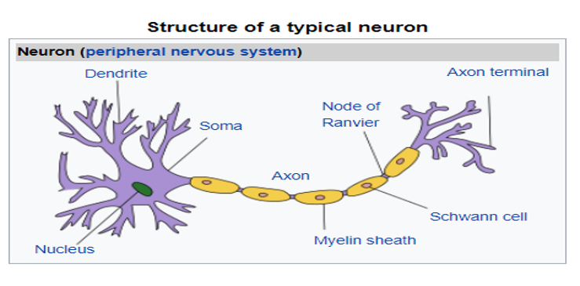

Human Neuron

- CC BY-SA 3.0 https://creativecommons.org/licenses/by-sa/3.0, via Wikimedia Commons
- For the human biological processes the incoming signals are received by the dendrites via a biochemical process which allows the weightage of these signals to be evaluated as per the importance or frequency of the impulse.
- The dendrite cell aggregates these impulse signals progressively until a threshold is reached consequent to which an output signal is generated via an electrochemical process through an axon.
- The axon further disseminates the signals to neighboring neurons , transmitting it through a gap called Synapse. The exact way of knowledge attainment or brain learning is elusive.

# Perceptron

- Basic unit of a neuron.A neural network has a input layer atleast one hidden layer and one output layer.Contains the inputs X1,X2 etc and there is a weight for these inputs w1,w2 etc. B is the bias.
- Like the brain this represents information transmission from one neuron to the other via dendrite signal initiation.

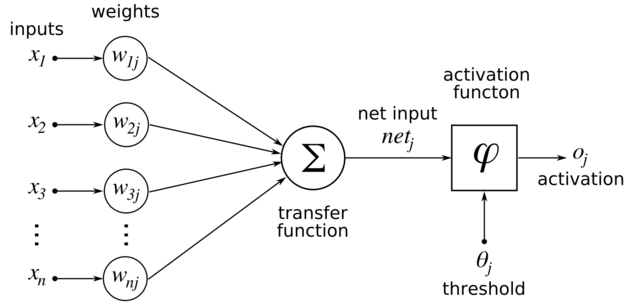

Simple Perceptron Neural

- CC BY-SA 3.0 https://creativecommons.org/licenses/by-sa/3.0, via Wikimedia Commons

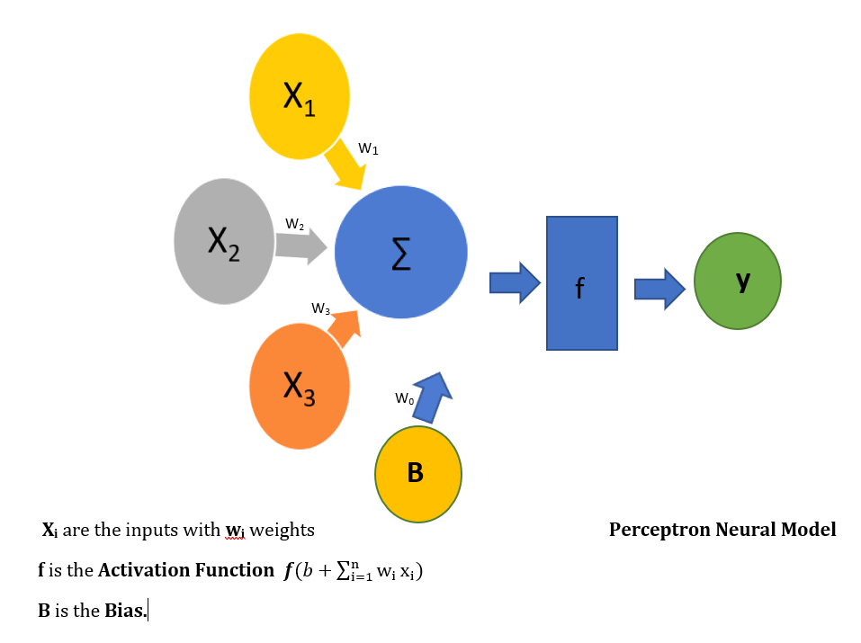

+ CC BY-SA 3.0 https://creativecommons.org/licenses/by-sa/3.0, via Wikimedia Commons

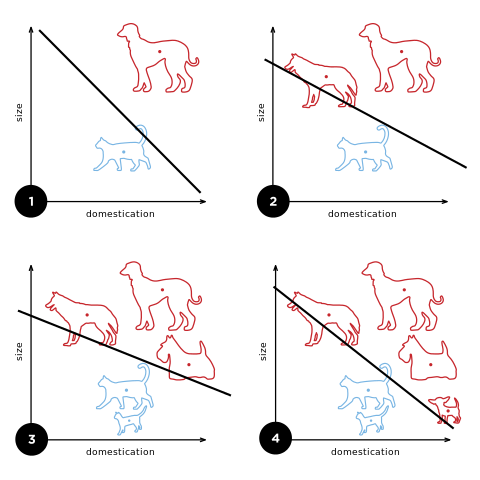

A diagram showing a perceptron updating its linear boundary as more training examples are added.

- **Bias** is like the intercept in the linear equation. It helps in shifting the activation function up and down left and right to help the model to the data. The Bias helps the model fit the data better. The value of bias is 1 and the weight is set by the algorithm.
- A single ANN neuron analogous to the brain neuron can be represented by input signals X1,X2 and X3 attaching the importance of these inputs by the numerical weights w1,w2 and w3. This is analogous to human dendrites. The weight significance is amplified or dampened by the neural network as per the learning process by evaluating the error perceived in the training process.
- The weighted input signals from each node at a level are cumulated, further processed by the activation function f which transforms them into outputs on the basis of a threshold reached. This is analogous to the cell’s mechanism of handling input signals.Once the threshold is achieved as per the activation function’s rule, the signal progresses through the network layers and finally an output is produced.
- The resulting outcome can be mathematically represented by the following relationship:

$$\mathbf{y(x) =f(\sum_{i=1}^{n}{w_ix_i})}$$

- ANN is composed of a network topology which incorporates the complex architectural frameworks of connected nodes(neurons) distributed across numerous layers which finally produce an output subsequent to the processing actualized by the activation function.
- Training algorithm are responsible for setting up the weights across the spectrum of nodes effectuating the inhibition or activation of neurons upon cumulation and activation function generation
- The initial neural network uses random guess technique for the weight assignment as it starts as a ignorant network and then learns progressivley with subsequent layers as well as forward and back propogations.

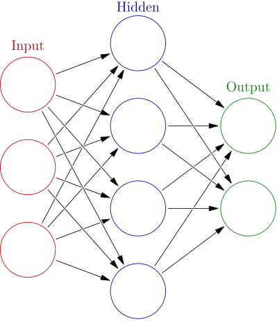

Neural Network

- CC BY-SA 3.0 https://creativecommons.org/licenses/by-sa/3.0, via Wikimedia Commons

# Activation Functions

- The paramount purpose of activation function is ascertaining if the aggregated weighted inputs have achieved a predefined threshold which results in the firing the output outcome signal.
- Activation functions can be quantified mathematically by various functional forms. The most common of these include Unit + Step activation functions, Sigmoid activation function, Linear activation function, Saturation Linear activation function, Hyperbolic Tangent activation function and Gaussian activation function.

**1.Unit Step Activation Function:**

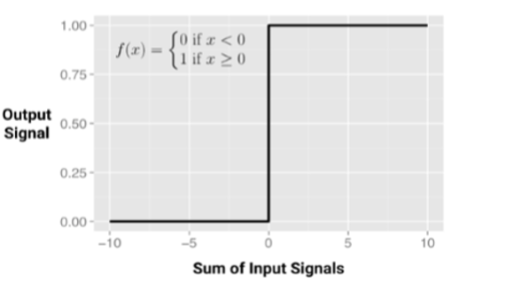

+ CC BY-SA 3.0 https://creativecommons.org/licenses/by-sa/3.0, via Wikimedia Commons

- This activation function generates the output signal once the sum of the weighted inputs equals more than zero. This threshold activation function does not mathematically represent the relationships between data very closely therefore it is not used very often.

**2.Sigmoid Activation Function**

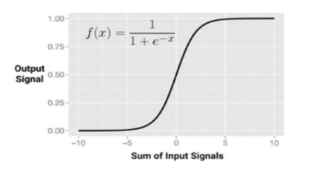

+ CC BY-SA 3.0 https://creativecommons.org/licenses/by-sa/3.0, via Wikimedia Commons

- The sigmoid function is the most commonly used activation function which is mathematically represented by the logistic sigmoid equation:

$$\mathbf{f(x)=\frac{1}{1+e^{-x}}}$$

- The output of the sigmoid activation function is no longer binary but in fact it is within the range 0-1 which is a better representation of the data. +Sigmoid function is differentiable therefore we can calculate the change of the output as per the change of inputs within a range of values. This property of Sigmoid activation function is helpful in optimizing the ANN algorithms. The sole disadvantage is that Sigmoid function is only limited to positive output values.To overcome this weakness the tanh activation is applied whose output range varies from -1 to 1.
- Activation Functions can be viewed on the following link: https://en.wikipedia.org/wiki/Activation_function

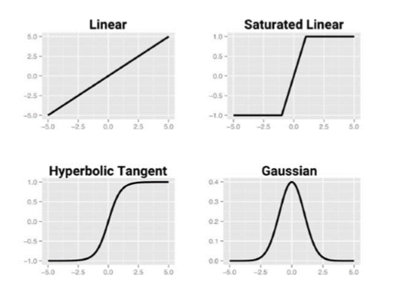

+ CC BY-SA 3.0 https://creativecommons.org/licenses/by-sa/3.0, via Wikimedia Commons

- Each of the activation function are uniquely set up in order to fit only certain types of data for example the linear activation function behaves like the regression model.
- Numerous Activation functions specifically Sigmoid functions have a issue related to the possible output ranges which are narrowly constrained within (0,1). Since input ranges are not constrained therefore corresponding to various input ranges, the output ranges will cluster at the boundaries of the range. To find the solution of the squashing problem the features are standardized or normalized in order to constrain the inputs within a range close to zero.
- The manipulation of the input data by the mechanism of standardization or normalization ensures that the large value features do not dominate the small valued features as well as the model is also trained quickly due to the bounded input values.

# Learning Rules

The ANN is adaptive in nature and continously learning as per the missclassification.

There are many learning rules that are used with neural network:

- **Least mean square**
- **Gradient descent**
- **Newton’s rule**
- **conjugate gradient**
- https://data-flair.training/blogs/learning-rules-in-neural-network/?utm_campaign=Submission&utm_medium=Community&utm_source=GrowthHackers.com

# ANN Architectural Framework

- The learning process of Neural Network in context of efficacy is primarily dependent on the number of layers, number of nodes within a layer as well as the ability of **back propogation**.Back propogation allow for weight assignment by gradient descent methodology that allows for error derivative propogation back into the network to improve the prediction or classification task.
- The complexity of the real-life scenarios can be modelled only by complicated neuron networks appropriately configured.
- Single layer network are used if the patterns are linearly separable but realistically the real life scenarios are more complex and require a more intricate multilayer network architecture. Typically these are problems that have a non linear structure.
- The intermediary layers within the multilayer neural networks are called **hidden layers** and in most cases the architecture is fully connected.
- If the network is unidirectional then these are called **feedforward networks** and if they are composed of multiple hidden layers then these are called **Deep Neural Network**. Such networks are called Deep Learning. There can be multiple outputs as well. The activation function is used for all the hidden as well as output layer. A fraction of the input is used for each layer to create intermediatory predictions and then this prediction is refined through the layers.
- The networks that allows the back propogation of signals are called **recurrent network** or feedback networks. These are more powerful that feedforward networks as they depict the real working of the biological neurons which represent real life scenarios. These help optimize the weights by the knowledge gained.
- Short term memory or **delay** is also very effective in obtaining the final outcomes over the continuum of time. This helps in learning from a sequence of events over a period of time. Stock market prediction can benefit from this ability.
- Back propagation networks are good for numerical classification, are able to model complex scenarios and make very few assumptions regarding the underlying data relationships.The back propogation is able to attribute the loss or the error in prediction and this is propogate back to generate better results wit the new learning.The loss is propogated through every layer including the hidden ones.The error accountability is determined with regards to the layers and the speific neuron and then the algorithm is retrained to effectuate a better prediction.Parameters can be adjusted as well as the weightages.of the predicting features.
- Back propogation causes the architecture to be computationally complex , might cause overfitting and be difficult to interpret due to the black box paradigm.
- The semantics of back-propogation entails the repeated iterations thorough the network path with each forward and backward traversal(onecycle) defined as an **epoch**.
- For the first epoch traversal gets initiated without a priori knowledge, the weights are assigned to the inputs at random. Once the forward phase is accomplished the output signal is fed into the backward phase which compares the output to the target feature value within the training data and the error that is perceived is propagated backwards to recalibrate the weights which typically improves the fit of the model.
- The technique used to optimize the weight assignment is achieved by the technique called **Gradient Descent**.
- The back propagation algorithm uses the derivative of the each neuron’s activation function in a manner that it identifies the magnitude of error increase/decrease as the weights change. The algorithm will try to achieve the maximum reduction of error by an amount quantified by lthe learning rate. The larger the learning rate the faster the algorithm will descent down the gradients.
- Conventionally Multilayer feedforward networks called Multilayer Perceptron are used for various ML implementations.
- The number of input nodes depend on the number of features in the input data and the outcome/outcomes depends on the number of class levels within the outcome.
- The number of hidden layers has to be determined by the user judiciously considering the tradeoff between number of input nodes, amount of training data, noise within the data and complexity of the learning procedure.
- Bias(how well the model fits the training data) and the variance( how well the model predicts the future examples with the training obtained) has to be optimized. Overfitting occurs when there is low bias but high variance and underfitting is when there is high bias and low variance.
- If the network architecture is too complex it might overfit the training data and these might be computationally expensive and slow to train.
- There are many techniques to avoid overfitting. These include retraining neural networks, multiple neural networks in parallel and averaging their outputs, early stopping criterion before model starts overfitting, **regularization** which adds a term in the error function to smoothen the outputs. Underfitting can be stopped by adding additional neurons,layers.

# Advantages

- Can implement both Classification and Numeric Predictions.
- Versatile enough to model very complicated relationships that might be non linear in nature.
- Makes no assumptions of the underlying pattern of the data so can be used to model volatile data and can generalize better for unseen data.

# Disadvantages

- Computationally intensive, slow to train.
- Network topology is complex which makes them difficult to interpret.
- Prone to overfit the training data.

# Mathematics of neural network

- https://juxt.pro/blog/posts/neural-maths.html
- Neuranetwork package details:
- https://www.rdocumentation.org/packages/nnet/versions/7.3-12/topics/nnet

# Deep Learning

# References

- https://towardsdatascience.com/introduction-to-neural-networks-advantages-and-applications-96851bd1a207
- https://en.wikipedia.org/wiki/Artificial_neural_network

[output not shown]